# The Decennial Census

Seven questions asked once a decade, and the people it does not find

Democracy’s Data

Last updated September 13, 2026 at 10:53a EDT

The Constitution orders a count. Article I, Section 2, Clause 3 requires an “actual Enumeration” of the whole population, once at the founding and then “within every subsequent Term of ten Years”.[^1] That is why the census falls in years ending in zero. **Actual Enumeration** means a head count rather than an estimate. The clause then hands Congress everything else, “in such Manner as they shall by Law direct.”

The Census Act is what Congress directed. It fixes a single day, 1 April, as Census Day, at 13 U.S.C. §141(a).[^2] Where a person was living on that day is where they are counted, whatever happened the week before or the week after. So the decennial census is a snapshot, one moment once a decade, and everything about the instrument follows from that.

What the count decides is representation. The state totals fix how many of the 435 House seats each state gets, and with them its votes in the Electoral College. Districts are the second job, because inside each state the same count is what maps are drawn from. Public Law 94-171, passed in 1975, obliges the Bureau to hand every state legislature small-area counts within a year of Census Day. Federal money follows the count as well, but apportionment is the constitutional job, and it is why this is an attempt to find everyone rather than a survey of some.

This chapter is about that count on its own terms: what it asks, what it publishes, what it costs, and, in the last third, who it does not find. Start with the thing people get wrong before anything else. The decennial census is not a rich source of information about Americans. It is an extraordinarily thin one.

## Where the data comes from, and what it is for

The **Census Bureau** runs the count and publishes the results. What this chapter reads is the 2020 **P.L. 94-171 redistricting file**, the one delivered to the states in August 2021. The Bureau delivers it one state at a time, as raw text files with no column headings, and it also publishes the same tables for the whole country as a single dataset; the national figures below come from that edition. Both are free to download at the addresses in the sources. Every count and every table width below is read out of the file itself rather than copied from its documentation.

**Who is in it, and how they got there.** Everyone living in the United States on 1 April 2020, at the address the Bureau’s published residence rules assign them.[^3] Three principles hold those rules together. Count people where they live and sleep most of the time. Count people in certain group facilities (prisons, dormitories, barracks, nursing homes) at the facility. Count people with no usual residence wherever they are on Census Day.

The second principle moves whole neighbourhoods. 8,239,016 people were counted at an address a rule assigned them rather than one they gave, and a rural district built around a large prison is built partly out of people the count placed there. The rules also say who is counted nowhere: a foreign visitor, a baby born on 2 April 2020, a person who died on 31 March. Federal employees stationed overseas are counted in their home state for apportionment only. And a residence rule can be undone after the fact. 6 states now move prisoners back to their home addresses before drawing their own maps, so what a legislature draws from is not always the file the Bureau delivered.[^4]

**Who it was made for.** Congress, whose seats the state totals divide, and the fifty legislatures, which redraw their districts from the small-area counts. The file breaks out one demographic line, people 18 and over. That line exists because Section 2 of the Voting Rights Act[^5] is enforced by comparing a minority group’s voting-age population against the rest of a district. Everyone else who divides by a census number is borrowing a legal record as a statistic.

**What it costs to get.** The file is free: open downloads, no key, no account. Producing it cost about $15.6 billion through 2023, by the Government Accountability Office’s reckoning, which is $47.07 for each person counted.

Both statutory delivery deadlines were missed in 2020–21, in a census that ran into a pandemic. The apportionment counts arrived 116 days after the date the statute names. The redistricting data arrived 133 days late, in the middle of the year the states had set aside to draw maps with it. A deadline in the United States Code is a commitment, not a guarantee.

**What has already been done to it.** The published counts below the state level are not the collected counts. A file detailed enough to describe one block by race and age can identify the people on it, so before release a formal privacy system added noise to everything beneath the state totals.[^6] The national 331,449,281 is the counted figure, and the state and block counts underneath were required to sum back to it. The alteration is invisible from inside the file — the chapter on what a census can and cannot do demonstrates that no internal check can find it. Separately, where nothing usable came back from an address, the Bureau fills in a guess from the records around it, which the Supreme Court has held is not sampling (*Utah v. Evans*, 2002).[^7]

## Seven questions

```
The 2020 census asked every household seven things. This is the
complete list -- there was no long form; it was retired after 2000.

  1. How many people were living here on April 1, 2020?
  2. Were there any additional people staying here that you did not
     include in Question 1?
  3. Is this house, apartment, or mobile home owned or rented?
  4. What is your telephone number?
  5. What is Person 1's name?
  6. What is Person 1's sex?  age?  date of birth?
  7. Is Person 1 of Hispanic, Latino, or Spanish origin?  What is
     Person 1's race?

Then, for each additional person, the relationship to Person 1.
```

Nothing about income, education, language, occupation, commuting, disability, veteran status, health insurance or ancestry. The “long form” that asked such things was retired after 2000. Its questions now live in the American Community Survey, a sample rather than a count. The ACS publishes a **margin of error**, a stated range for how far off each estimate could be, beside every number. So when a claim about income or language is attributed to “the census”, it did not come from the census. The telephone number is never published; it is there so the Bureau can call back about a missing or contradictory answer.

An eighth question was nearly added, and the fight over it went to the Supreme Court. In 2018 the Secretary of Commerce directed the Bureau to ask every household about citizenship, which the form last did in 1950. In *Department of Commerce v. New York* (2019)[^8] the Court held that the Secretary had the authority to ask, and also that the reason he gave did not match the record. The administration dropped the question in July 2019, and the form above is what went out.

## What seven questions become

The shape of the published file is set by statute, not by the Bureau. Public Law 94-171 tells it to give the states small-area counts of population, of people old enough to vote, of race and Hispanic origin, of housing, and of group quarters. That list is the file:

| Table | Variables | What it counts |
| --- | --- | --- |
| P1 | 71 | Everyone, by race |
| P2 | 73 | Everyone, by Hispanic origin and race |
| P3 | 71 | People 18 and over, by race |
| P4 | 73 | People 18 and over, by Hispanic origin and race |
| H1 | 3 | Housing units: total, occupied, vacant |
| P5 | 10 | People living in group quarters, by type of institution |

**6 tables. 301 numbers per geography.** That is what the country redraws itself from. The file repeats it at every level of census geography, from the state down to each census block, the smallest area the Bureau publishes and often a single city block — the demographics brief reads the same counts at eight of those levels.

Now watch the width accumulate, because it comes almost entirely from the last question on the form. A count on its own is one number per place. Broken out by race it becomes P1’s 71 cells. Add Hispanic origin, and P1 and P2 together are 144. Apply the 18-and-over line to both and they double to 288 across P1 through P4 — **288 of the 301 numbers in the file exist because of one question.**

Of P1’s 71 cells, 57 count specific *combinations* of races, most holding very small numbers. That is a fact about the question rather than about the population, and it is the race brief’s subject.

Everything the file reports about the country that is not a race cell fits in two sentences. There were 331,449,281 people on Census Day, 258,343,281 of them 18 or over, living in 140,498,736 housing units of which 13,681,156 stood empty. Another 8,239,016 were counted in group quarters rather than households. The race cells are the rest of it, and they are where the width went.

| Group | People | Share of the country |
| --- | --- | --- |
| White alone | 204,277,273 | 61.6% |
| Black or African American alone | 41,104,200 | 12.4% |
| American Indian or Alaska Native alone | 3,727,135 | 1.1% |
| Asian alone | 19,886,049 | 6.0% |
| Native Hawaiian or Other Pacific Islander alone | 689,966 | 0.2% |
| Some Other Race alone | 27,915,715 | 8.4% |
| Two or more races | 33,848,943 | 10.2% |
| Hispanic or Latino, of any race | 62,080,044 | 18.7% |

The decennial resolves the country finely in **space** and hardly at all in **subject**. That trade is what the census is.

One more thing the statute does not do. It obliges the Bureau to deliver this file to every legislature, and it obliges no legislature to open it. By the National Conference of State Legislatures’ state-by-state reading,[^9] 24 states have written the federal count into their own law for legislative districts. Another 18 rely on it without writing it down, and in 6 states nothing requires it at all.

## The count is not complete, and it never has been

A census attempts to count everyone and does not succeed. The Bureau knows this, measures it, and says so. After each census it runs a separate survey, the Post-Enumeration Survey, in which interviewers go back to a sample of blocks, count everyone living there again from scratch, and match the two lists person by person; from that it estimates how far off the count was, and for whom.[^10]

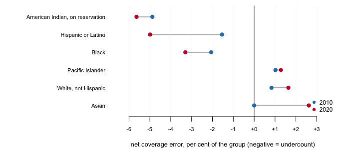

**Figure 1. Net coverage error by group: the 2010 census against the 2020 census.** A negative number is an undercount. Each group has exactly two measurements, a decade apart, and that is why the chart is a pair of dots joined by a line rather than a pair of bars. The dots place each census against a perfect count at zero, and the line between them is the movement — what to read is its direction. Black, Hispanic and American Indian residents sit below zero in both censuses; non-Hispanic White residents sit above it in both. And between 2010 and 2020 the ends moved apart, not together.

The figure hides one discipline the numbers demand, so here is the same table with the Bureau’s own significance tests attached — its judgment, given the survey’s margin of error, of whether a difference is large enough to be real rather than chance:

| Group | Net 2020 | Net 2010 | Change | Differs from zero | Differs from 2010 |
| --- | --- | --- | --- | --- | --- |
| Black or African American | -3.30% | -2.06% | -1.24 | Yes | No |
| American Indian or Alaska Native, on reservation | -5.64% | -4.88% | -0.76 | Yes | No |
| Hispanic or Latino | -4.99% | -1.54% | -3.45 | Yes | Yes |
| Native Hawaiian or Other Pacific Islander | +1.28% | +1.02% | +0.26 | No | No |
| Asian | +2.62% | 0.00% | +2.62 | Yes | Yes |
| White, not Hispanic | +1.64% | +0.83% | +0.81 | Yes | Yes |

The last two columns are two different questions, and keeping them apart is the whole skill of reading this table. **Differs from zero** asks whether the 2020 rate is distinguishable from a perfect count. **Differs from 2010** asks whether the 2020 rate is distinguishable from the one before it. Subtraction will hand you a Change for every row; only the rows marked Yes in the last column have earned one.

Read the 2020 column first: **Black residents, 3.30% undercounted; Hispanic residents, 4.99% undercounted; American Indian residents on reservations, 5.64% undercounted; White, not Hispanic residents, 1.64% *over*counted.** Now read the change column through the filter of the last column. Against 2010 the Hispanic undercount deepened by 3.45 points and the non-Hispanic White overcount grew by 0.81 — two movements in opposite directions, both of which the Bureau calls real. **The gap did not narrow between 2010 and 2020. It widened at both ends.**

The Black undercount and the undercount on reservations also sit deeper in 2020, but the Bureau cannot tell either movement apart from 2010. So the honest claim there is not that they grew. It is that they were large in 2010 and are large still.

This is the single most important thing to carry out of this chapter. The census is not wrong in a random direction. It is wrong by different amounts for different groups, in the same direction, census after census. Every rate in this book with a census population as its **denominator**, the bottom number of the fraction, inherits that error silently. The coverage brief reads the Bureau’s estimates in their own detail, state by state; this chapter carries only the headline.

Percentages are easy to nod at, so here is what those rates are in bodies, against the published counts they were measured on:

| Group | Published count | National rate | Implied people |
| --- | --- | --- | --- |
| Black or African American alone | 41,104,200 | -3.30% | 1,402,729 missed |
| Hispanic or Latino, of any race | 62,080,044 | -4.99% | 3,260,493 missed |
| White alone, not Hispanic | 191,697,647 | +1.64% | 3,093,114 in excess |

The count is wrong in a patterned direction, the Bureau measures how wrong, and the law will not let anyone fix it. **The apportionment count may not be adjusted by sampling** — measuring part of a population carefully and scaling the answer up. The Supreme Court read 13 U.S.C. §195[^11] to bar that, in *Department of Commerce v. U.S. House of Representatives* (1999).[^12]

And the Bureau is not obliged to adjust even when it holds the measurement. After the 1990 census the Secretary declined to correct the published count with that decade’s survey, and *Wisconsin v. City of New York* (1996) upheld the refusal.[^13] So the published count is the count that governs, and the Bureau’s own estimate of how far off it is arrives separately, in a document nothing is required to act on. **A census is a legal object first and a measurement second.**

## What this data cannot tell you

**The coverage rates come from a press release, not a data file.** The Bureau publishes the Post-Enumeration Survey results as PDFs and press releases rather than as data, so the six rows of the coverage table were transcribed from the March 2022 release. If the Bureau revised them, nothing here would notice. Everything else is read out of the file itself or computed from the statutory dates, and moves when they move.

**Six groups are shown; the Bureau reported more.** It also found an undercount for the Some Other Race population, a rate not carried here. And one of the six rows, Native Hawaiian or Other Pacific Islander, is the Bureau’s own “not distinguishable from zero”. It is carried rather than dropped, because a coverage table showing only the clear rows reads like a verdict rather than a measurement.

**The Bureau’s race groups are broader than the count table’s.** Coverage for Black, Asian, American Indian and Pacific Islander residents is reported *alone or in combination*: everyone who marked that race, whether or not they marked another beside it. The counts here are the *alone* categories, so for the Black row the implied figure is, if anything, on the low side.

**Net coverage error is not the same as accuracy.** A net rate near zero can hide a large undercount and a large overcount cancelling each other out, and the PES measures the household population; people in group quarters are handled separately. “How close did it come” is a bigger question than one number per group.

**The state-law counts are frozen at 2019.** They were transcribed from NCSL’s *Redistricting Law 2020*, whose own summary paragraph disagrees with its state-by-state appendix; the appendix is the per-state authority, so the appendix is what the numbers follow. A state that has amended its law since would still appear here as it stood then.

**Five residence situations are described; the rule has dozens.** The Bureau’s residence criteria run to pages of living arrangements, and nothing in the published file says how many people any one rule moved.

**A national figure hides every state.** Housing vacancy, group-quarters share and racial composition all differ enormously by state, and nothing above shows that spread. What does not differ is the shape of the count: seven questions, 6 tables, once a decade, delivered one state at a time.

Finally, keep the two kinds of wrongness apart, because they are opposite problems. The privacy noise is deliberate, documented, applied to the file after the count, and undetectable from inside it. An undercount is unintended, happens out in the field, and can only be found by going back out with a second survey and looking.

## What you should have learned

- The whole instrument is seven questions, and the published redistricting file is 6 tables — 301 numbers per place, 288 of them produced by the race question alone.
- The count is a snapshot of one day, taken at addresses the residence rules assign: 8,239,016 people were counted at group quarters rather than at a home they chose.
- The count misses people unevenly and in the same direction each time. In 2020 it undercounted Black residents by 3.30%, Hispanic residents by 4.99%, and overcounted non-Hispanic White residents by 1.64% — and the 2010–2020 gap widened at both ends.
- The law makes the published count the count that governs: no sampling for apportionment, and no obligation to adjust even when the Bureau holds the measurement.
- Counting the country cost about $15.6 billion, $47.07 per person counted, and both statutory delivery deadlines were still missed — by 116 and 133 days.

## Where this data appears in this book

This chapter anchors the cluster on the decennial census. Each brief in the cluster asks one question of the count introduced here:

- Apportionment: How a Count Becomes Seats — the constitutional purpose carried out: the formula, and a seat decided by a margin smaller than the instrument’s error.
- Regional Population Shift and House Seats — six reapportionments laid end to end, and the region that lost its majority of the House.
- Measuring Race at Eight Geographic Scales — the same race counts read at every level the file publishes, and why only the smallest describes anyone.
- When a Scatter Plot Has Too Many Points — every populated Georgia block on one chart, and what that density does to a scatter plot.

## Sources

**Data**

- U.S. Census Bureau. *2020 Census P.L. 94-171 Redistricting Data Summary File* — the file as delivered to the states in August 2021. It ships one state at a time, as raw text files with no column headings, so the layout documentation published beside it is not optional if you use it that way. https://www.census.gov/programs-surveys/decennial-census/about/rdo/summary-files.html The counts above are the same tables for the whole country, which the Bureau also publishes as one national dataset, `2020/dec/pl` (https://api.census.gov/data/2020/dec/pl); a free key is needed to download it. The two editions carry the same numbers: `legacy_georgia.csv` holds Georgia’s totals as they appear in the state-by-state delivery, and they match the national dataset to the person.
- U.S. Census Bureau. “Census Bureau Releases Estimates of Undercount and Overcount in the 2020 Census”, release CB22-CN.02, 10 March 2022 — the 2020 Post-Enumeration Survey against the 2010 Census Coverage Measurement survey. https://www.census.gov/newsroom/press-releases/2022/2020-census-estimates-of-undercount-and-overcount.html
- U.S. Census Bureau. *2020 Census Questionnaire*, and the 2020 Census Apportionment Results, 26 April 2021.
- U.S. Government Accountability Office. *2020 Census*, high-risk series — the cost figure through 2023. https://www.gao.gov/highrisk/decennial-census
- U.S. Census Bureau. *Disclosure Avoidance for the 2020 Census: An Introduction*, 2021 — the Bureau’s own account of the noise added below the state level, and of which totals were held invariant. https://www.census.gov/library/publications/2021/decennial/2020-census-disclosure-avoidance-handbook.html
- National Conference of State Legislatures. *Redistricting Law 2020*. Denver: NCSL, October 2019 — Chapter 1 (The Census), Appendix A (Census Residence Concepts) and Appendix B (Redistricting and the Use of Census Data). The state-law counts are computed from a transcription of Appendix B; the residence rules and the prisoner-reallocation counts come from Chapter 1 and Appendix C.
- U.S. Census Bureau. *Final 2020 Census Residence Criteria and Residence Situations*, 83 Fed. Reg. 5525 (8 February 2018). https://www.federalregister.gov/documents/2018/02/08/2018-02370/final-2020-census-residence-criteria-and-residence-situations

**The data itself**

Every figure above is drawn from these tables. They are plain CSV, they open in a spreadsheet, and they are yours to take further.

`adjustments.csv`, `census-use.csv`, `cost.csv`, `coverage.csv`, `deadlines.csv`, `legacy_georgia.csv`, `national.csv`, `race.csv`, `scale.csv`, `tables.csv`

**Your turn**

None of these is answered above, and every one can be answered from the tables you just opened.

- `deadlines.csv` records what the statute required, what was delivered, and `days_late`. Both deadlines were missed. Work out who was waiting on each one and what they could not do meanwhile.
- `scale.csv` applies a national coverage rate (`national_rate`) to a state’s published count to get `implied_people`. Do that arithmetic yourself for a different group. What does the size of the answer do to your confidence in the published number?
- `tables.csv` says how many `cells` come out of each published table. Multiply out what seven questions become. Where do all those cells come from, if only seven things were asked?
- `race.csv` gives each group’s `share_of_us`. Add the shares. If they do not come to a hundred, work out why before you decide it is an error.
- `census-use.csv` counts states by what their own law says about using the federal count (`legislative`, `congressional`). Which arrangement surprises you more — a state obliged by its own constitution, or a state obliged by nothing? What would the second kind of state need, to draw maps without the Bureau?

**Statutes**

- U.S. Const. art. I, § 2, cl. 3 (the “actual Enumeration” clause). https://www.archives.gov/founding-docs/constitution-transcript
- Census Act, 13 U.S.C. § 141(a) (April 1 as the decennial census date), § 141(b) (apportionment counts to the President), and § 141(c) (redistricting data to the states), the last enacted as Public Law 94-171 (1975). https://www.law.cornell.edu/uscode/text/13/141
- 13 U.S.C. § 195 (sampling, except for apportionment). https://www.law.cornell.edu/uscode/text/13/195
- 2 U.S.C. § 2a (apportioning the seats from the counts). https://www.law.cornell.edu/uscode/text/2/2a
- Voting Rights Act § 2, 52 U.S.C. § 10301 (the reason the file carries a voting-age line). https://www.law.cornell.edu/uscode/text/52/10301

**Cases**

- *Wisconsin v. City of New York*, 517 U.S. 1 (1996). https://www.law.cornell.edu/supremecourt/text/517/1
- *Department of Commerce v. U.S. House of Representatives*, 525 U.S. 316 (1999). https://www.law.cornell.edu/supremecourt/text/525/316
- *Utah v. Evans*, 536 U.S. 452 (2002). https://www.law.cornell.edu/supremecourt/text/536/452
- *Department of Commerce v. New York*, 588 U.S. 752 (2019). https://www.law.cornell.edu/supremecourt/text/18-966

Rebuild this data yourself, with an AI assistant

```
I want to rebuild a public dataset from its original source, without any
starting files. Please do the following and show your work.

THE SOURCE. U.S. Census Bureau, 2020 Census P.L. 94-171 Redistricting
Data Summary File -- the file the Bureau is required by law to hand
every state so it can draw districts. It is published two ways, and
which one you pick matters here.

The Census data API serves it as the dataset 2020/dec/pl:
https://api.census.gov/data/2020/dec/pl
A free key is required (https://api.census.gov/data/key_signup.html);
an unkeyed request redirects to a "missing key" page. Ask for
&for=us:* to get the national row, and &for=state:13 for Georgia. The
answer is JSON: an array of arrays with the header row first.

The same file is also published in legacy format, one zip per state,
under
https://www2.census.gov/programs-surveys/decennial/2020/data/01-Redistricting_File--PL_94-171/
No key is needed for those, but the file is delivered STATE BY STATE
and there is no national archive of it, so the whole country is
fifty-one downloads and about 1.3 GB. Each zip holds four
pipe-delimited files with no headers: a geographic header, one row per
geographic unit, and three data segments joining to it on LOGRECNO.
Summary level 040 is the state; 050 is a county. In segment 1, Table
P1 (race) starts at field 6 and Table P2 (Hispanic origin by race) at
field 77; segment 2 carries P3, P4 and H1 (housing); segment 3 carries
P5 (group quarters).

WHAT TO BUILD.
1. A table of how WIDE each of the file's six tables is -- P1, P2, P3,
   P4, H1, P5 -- measured rather than copied out of the documentation.
   The API publishes variables.json listing every cell it serves, with
   the table each one belongs to; count them there.
2. A table of what those six tables say about the whole country: total
   population, population 18 and over, population in group quarters,
   and housing units split into occupied and vacant.
3. The population by race and by Hispanic origin: the six race-alone
   categories, two or more races, and Hispanic or Latino of any race.
   Note that the last one is not a race and does not belong in a sum
   with the other seven.
4. If you use the API, satisfy yourself it really is the same file:
   pull Georgia both ways and compare every cell. Do not assume two
   deliveries of a file agree because they are supposed to.

CHECK YOUR WORK. The copies this book used were downloaded in September
2026. If your rebuild matches them, you should find:
- six tables, of 71, 73, 71, 73, 3 and 10 cells
- a national total population of 331449281, of whom 258343281 are 18
  and over and 8239016 live in group quarters
- 140498736 housing units, of which 13681156 stood vacant
- Georgia, if you download it as the cross-check, with a total population
  of 10711908
Nearly all of that width is the race question: P1 through P4 are 288
of the file's cells, and only 13 are housing and group quarters.
These are the final legal files of the 2020 census; nothing in them
will change before the 2030 cycle.
```

[^1]: U.S. Const. art. I, § 2, cl. 3, text at the National Archives: https://www.archives.gov/founding-docs/constitution-transcript.
[^2]: Census Act, 13 U.S.C. § 141: https://www.law.cornell.edu/uscode/text/13/141.
[^3]: *Final 2020 Census Residence Criteria and Residence Situations*, 83 Fed. Reg. 5525 (8 February 2018): https://www.federalregister.gov/documents/2018/02/08/2018-02370/final-2020-census-residence-criteria-and-residence-situations.
[^4]: Counted from the National Conference of State Legislatures, *Redistricting Law 2020* (October 2019): https://www.ncsl.org/redistricting-and-census/redistricting-law-2020.
[^5]: 52 U.S.C. § 10301: https://www.law.cornell.edu/uscode/text/52/10301.
[^6]: The Bureau’s own account: *Disclosure Avoidance for the 2020 Census: An Introduction* (2021), https://www.census.gov/library/publications/2021/decennial/2020-census-disclosure-avoidance-handbook.html.
[^7]: 536 U.S. 452 (2002): https://www.law.cornell.edu/supremecourt/text/536/452.
[^8]: 588 U.S. 752 (2019): https://www.law.cornell.edu/supremecourt/text/18-966.
[^9]: NCSL, *Redistricting Law 2020*, Appendix B: https://www.ncsl.org/redistricting-and-census/redistricting-law-2020.
[^10]: The 2020 results were announced in “Census Bureau Releases Estimates of Undercount and Overcount in the 2020 Census” (10 March 2022): https://www.census.gov/newsroom/press-releases/2022/2020-census-estimates-of-undercount-and-overcount.html.
[^11]: Census Act, 13 U.S.C. § 195: https://www.law.cornell.edu/uscode/text/13/195.
[^12]: 525 U.S. 316 (1999): https://www.law.cornell.edu/supremecourt/text/525/316.
[^13]: 517 U.S. 1 (1996): https://www.law.cornell.edu/supremecourt/text/517/1.